# Hw3

Problem 1

1a. For Algorithm 1 Probability of correct People 47/52 = 90.38% Probability of correct Birds 45/48 = 93.75%

For Algorithm 2 Probability of correct People 42/52 = 80.77% Probability of correct Birds 47/48 = 97.92%

Overall, the average probability for indetifying the correct person or bird for algorithm 1 is 92.07%, and for algorithm 2 is 89.35%, so algorithm 1 makes fewer mistakes.

1b. For algorithm 2, the chance of detecting the correct bird is 97.92%, which is a lot higher than algorithm 1, 93.75%. It is better for the zoo to have a higher probability at recognizing the correct bird so they do not allow birds out on accident, and to the zoo they will proritize a higher probability for detecting the correct bird than people.

1c. Algorithm 1 True Bird True Person NN Bird 92 7 NN Person 7 8

Algorithm 2 True Bird True Person NN Bird 97 2 NN Person 2 3

Problem 2

```python
#Import libraries
import numpy as np
import scipy
from scipy import stats
import matplotlib
import matplotlib.pyplot as plt

#2a
x1 = np.arange(0,10)
y1 = stats.expon.pdf(x,loc=3, scale=1)
x2 = np.arange(0, 19)
y2= np.convolve(y1, y1)
```

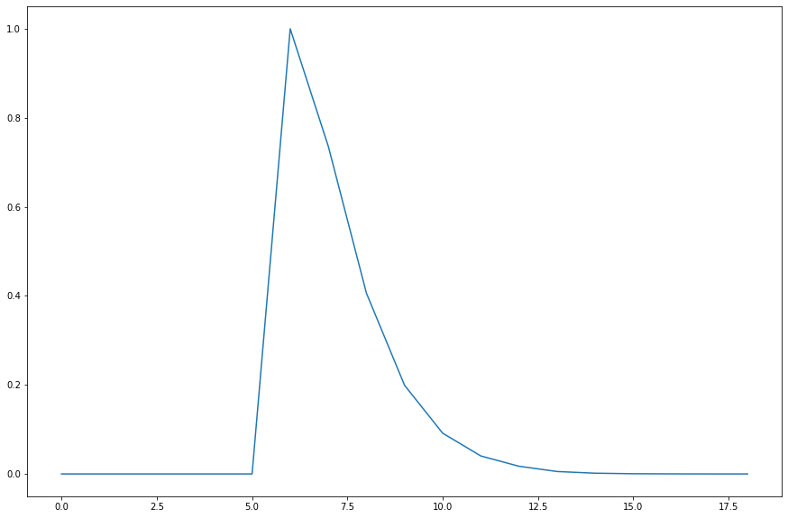

```python
plt.rcParams["figure.figsize"] = (15,10)
fig, ax = plt.subplots(1, 1)
ax.plot(x2,y2);
plt.show();
```

```python
#2b
x1 = np.arange(0,10)
y1 = stats.norm.pdf(x,loc=3, scale=1)
x2 = np.arange(0, 10)
y2= y1 / y1
```

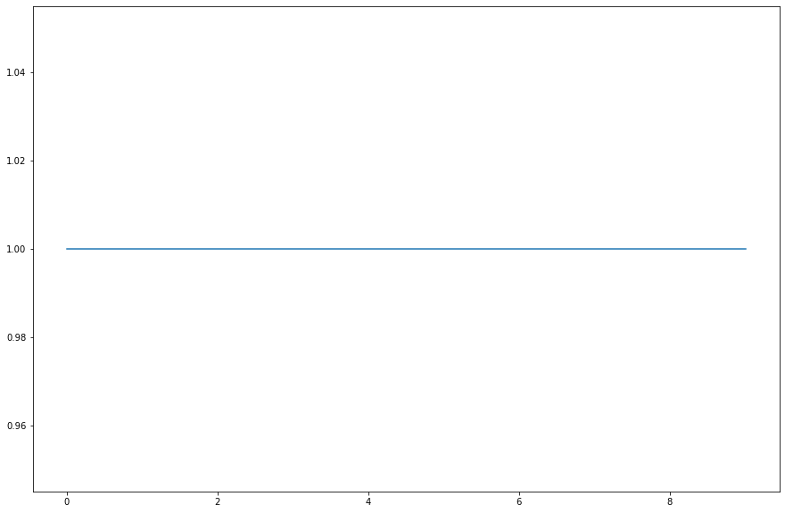

```python
plt.rcParams["figure.figsize"] = (15,10)
fig, ax = plt.subplots(1, 1)
ax.plot(x2,y2);
plt.show();
```

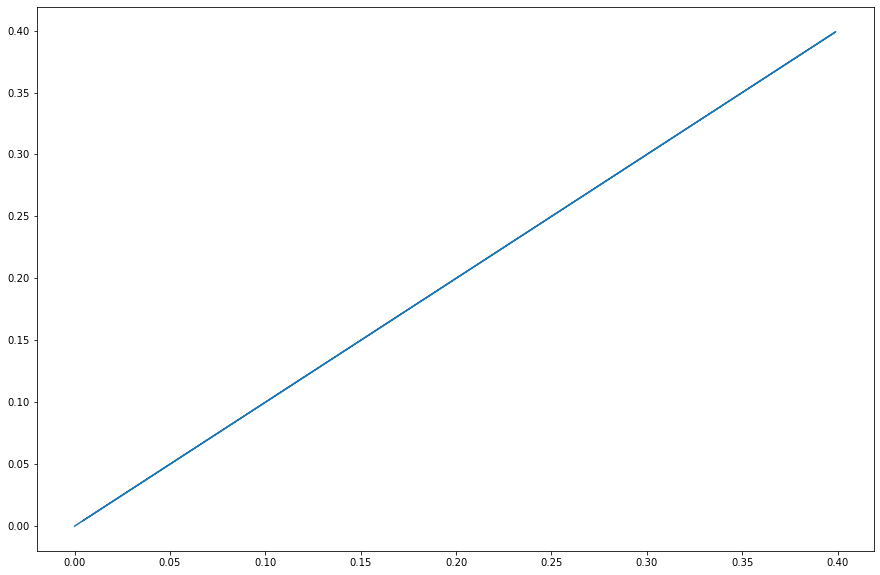

```python
#2c
x1 = np.arange(0,10)
y1 = stats.norm.pdf(x1,loc=3, scale=1)
x2 = np.arange(0,10)
y2 = stats.norm.pdf(x2,loc=3, scale=1)
plt.rcParams["figure.figsize"] = (15,10)
fig, ax = plt.subplots(1, 1)
ax.plot(y1,y2);
plt.show();
```

Since both x and y are both from gaussian distribution, the pdf will be a line that has a slope of one and it will always be positive.